# Estudo de Caso: Efeito Coattail Presidencial nas Eleições Distritais do DF (2006–2022)

#### Top 3 Partidos que mais recebem votos por RA para Deputado Distrital em 2014

```r
# Criar o Dataframe com os dados dos top 3 partidos mais votados para Deputado distrital por zona em 2014
df_mais_votos_patido_deputado_por_zona_2014 <- df_resultado_eleicao %>%
  filter(cargo == "deputado distrital", ano == 2014) %>%
  group_by(sigla_partido, zona) %>%
  summarise(votos_total = sum(votos)) %>%
  arrange(zona, desc(votos_total)) %>%
  group_by(zona) %>%
  slice_head(n = 3)
```

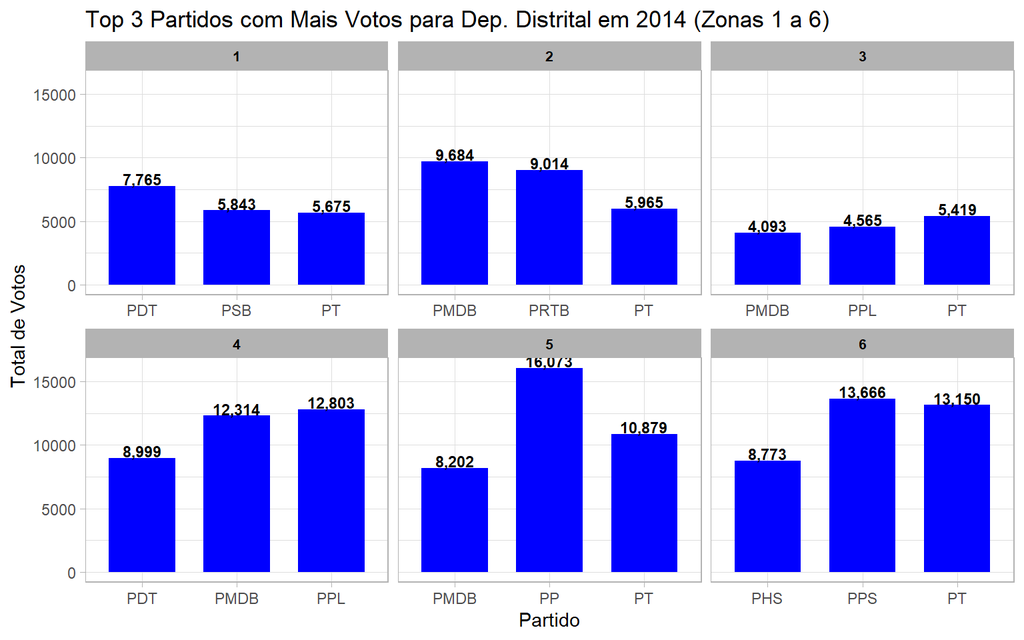

```r
# Criar gráfico das zonas 1 a 6
ggplot(
  data = df_mais_votos_patido_deputado_por_zona_2014 %>% filter(zona < 7),
  mapping = aes(x = sigla_partido, y = votos_total)) +
  geom_col(fill = "blue", width = 0.7) +
  geom_text(aes(label = scales::comma(votos_total)),
            hjust = 0.5,
            vjust = -0.1,
            color = "black",
            size = 3,
            fontface = "bold") +
  facet_wrap(~ zona, scales = "free_x") +
  theme_light() +
  labs(
    title = "Top 3 Partidos com Mais Votos para Dep. Distrital em 2014 (Zonas 1 a 6)",
    x = "Partido",
    y = "Total de Votos"
  ) +
theme(
  strip.text = element_text(
    face = "bold",
    color = "black",
    size = 8)
)
```

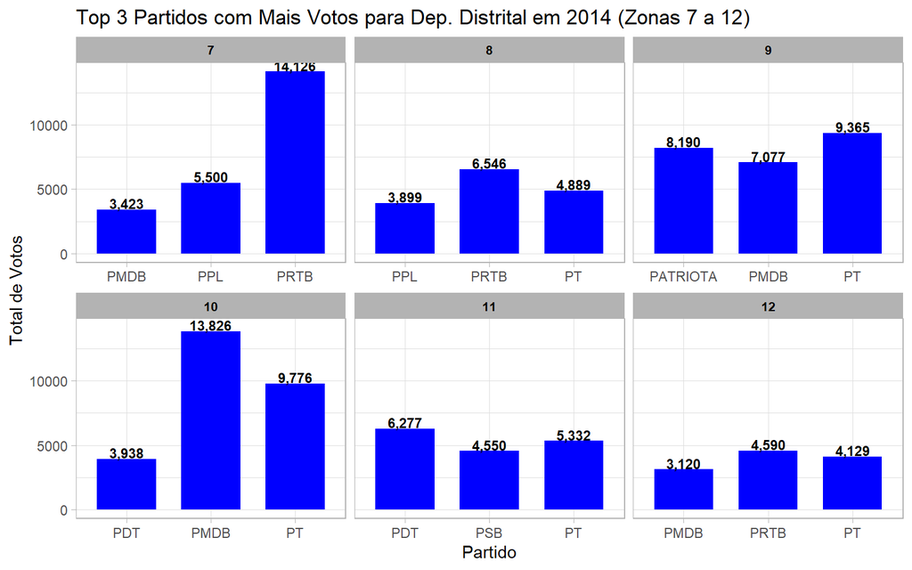

```r
# Criar gráfico das zonas 6 a 11
ggplot(
  data = df_mais_votos_patido_deputado_por_zona_2014 %>% filter(zona > 6 & zona < 13),
  mapping = aes(x = sigla_partido, y = votos_total)) +
  geom_col(fill = "blue", width = 0.7) +
  geom_text(aes(label = scales::comma(votos_total)),
            hjust = 0.5,
            vjust = -0.1,
            color = "black",
            size = 3,
            fontface = "bold") +
  facet_wrap(~ zona, scales = "free_x") +
  theme_light() +
  labs(
    title = "Top 3 Partidos com Mais Votos para Dep. Distrital em 2014 (Zonas 7 a 12)",
    x = "Partido",
    y = "Total de Votos"
  ) +
theme(
  strip.text = element_text(
    face = "bold",
    color = "black",
    size = 8)
)
```

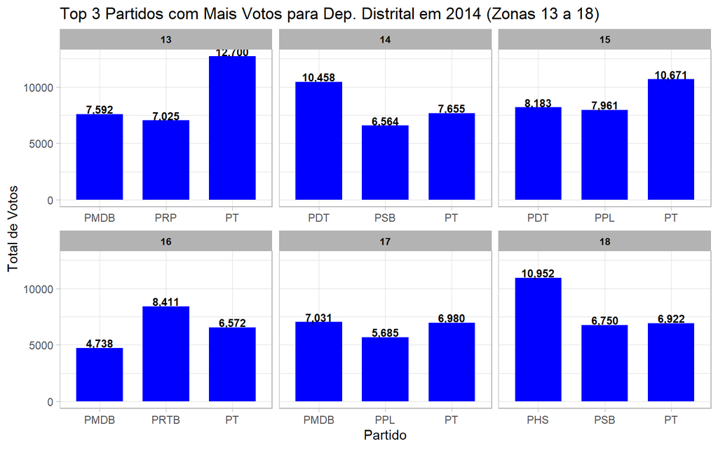

```r
# Criar gráfico das zonas de 13 a 19
ggplot(
  data = df_mais_votos_patido_deputado_por_zona_2014 %>% filter(zona > 12 & zona < 19),
  mapping = aes(x = sigla_partido, y = votos_total)) +
  geom_col(fill = "blue", width = 0.7) +
  geom_text(aes(label = scales::comma(votos_total)),
            hjust = 0.5,
            vjust = -0.1,
            color = "black",
            size = 3,
            fontface = "bold") +
  facet_wrap(~ zona, scales = "free_x") +
  theme_light() +
  labs(
    title = "Top 3 Partidos com Mais Votos para Dep. Distrital em 2014 (Zonas 13 a 18)",
    x = "Partido",
    y = "Total de Votos"
  ) +
theme(
  strip.text = element_text(
    face = "bold",
    color = "black",
    size = 8)
)
```

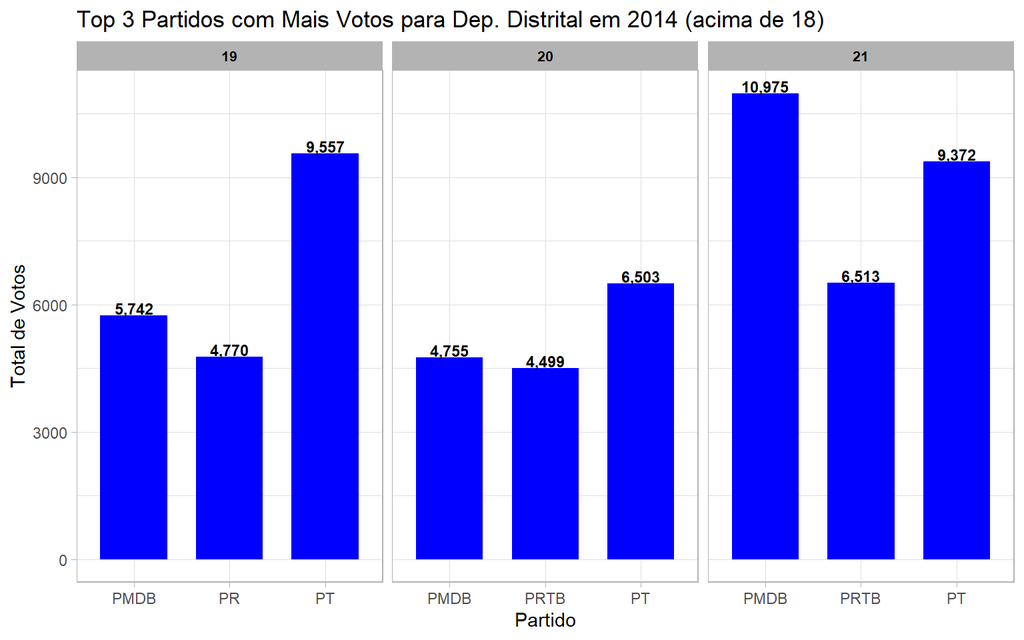

```r
# Criar gráfico das zonas acima de 19
ggplot(
  data = df_mais_votos_patido_deputado_por_zona_2014 %>% filter(zona > 18),
  mapping = aes(x = sigla_partido, y = votos_total)) +
  geom_col(fill = "blue", width = 0.7) +
  geom_text(aes(label = scales::comma(votos_total)),
            hjust = 0.5,
            vjust = -0.1,
            color = "black",
            size = 3,
            fontface = "bold") +
  facet_wrap(~ zona, scales = "free_x") +
  theme_light() +
  labs(
    title = "Top 3 Partidos com Mais Votos para Dep. Distrital em 2014 (acima de 18)",
    x = "Partido",
    y = "Total de Votos"
  ) +
theme(
  strip.text = element_text(
    face = "bold",
    color = "black",
    size = 8)
)
```

Com base nos gráficos de 2014, pode-se observar que:

```r
# Criar o Dataframe com os dados dos top 3 partidos mais votados para Deputado distrital por zona em 2018
df_mais_votos_patido_deputado_por_zona_2018 <- df_resultado_eleicao %>%
  filter(cargo == "deputado distrital", ano == 2018) %>%
  group_by(sigla_partido, zona) %>%
  summarise(votos_total = sum(votos)) %>%
  arrange(zona, desc(votos_total)) %>%
  group_by(zona) %>%
  slice_head(n = 3)
```

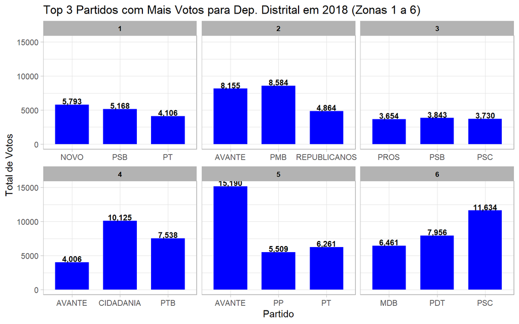

```r
# Criar gráfico das zonas 1 a 6
ggplot(
  data = df_mais_votos_patido_deputado_por_zona_2018 %>% filter(zona < 7),
  mapping = aes(x = sigla_partido, y = votos_total)) +
  geom_col(fill = "blue", width = 0.7) +
  geom_text(aes(label = scales::comma(votos_total)),
            hjust = 0.5,
            vjust = -0.1,
            color = "black",
            size = 3,
            fontface = "bold") +
  facet_wrap(~ zona, scales = "free_x") +
  theme_light() +
  labs(
    title = "Top 3 Partidos com Mais Votos para Dep. Distrital em 2018 (Zonas 1 a 6)",
    x = "Partido",
    y = "Total de Votos"
  ) +
theme(
  strip.text = element_text(
    face = "bold",
    color = "black",
    size = 8)
)
```

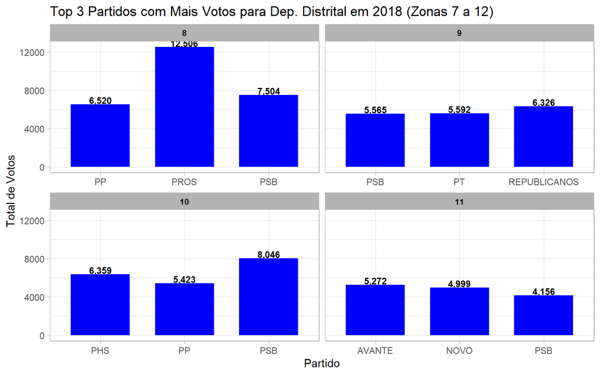

```r
# Criar gráfico das zonas 6 a 11
ggplot(
  data = df_mais_votos_patido_deputado_por_zona_2018 %>% filter(zona > 6 & zona < 13),
  mapping = aes(x = sigla_partido, y = votos_total)) +
  geom_col(fill = "blue", width = 0.7) +
  geom_text(aes(label = scales::comma(votos_total)),
            hjust = 0.5,
            vjust = -0.1,
            color = "black",
            size = 3,
            fontface = "bold") +
  facet_wrap(~ zona, scales = "free_x") +
  theme_light() +
  labs(
    title = "Top 3 Partidos com Mais Votos para Dep. Distrital em 2018 (Zonas 7 a 12)",
    x = "Partido",
    y = "Total de Votos"
  ) +
theme(
  strip.text = element_text(
    face = "bold",
    color = "black",
    size = 8)
)
```

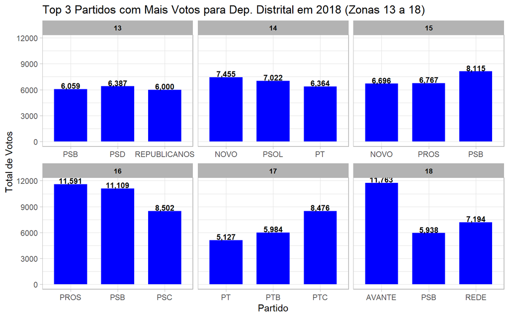

```r
# Criar gráfico das zonas de 13 a 19
ggplot(
  data = df_mais_votos_patido_deputado_por_zona_2018 %>% filter(zona > 12 & zona < 19),
  mapping = aes(x = sigla_partido, y = votos_total)) +
  geom_col(fill = "blue", width = 0.7) +
  geom_text(aes(label = scales::comma(votos_total)),
            hjust = 0.5,
            vjust = -0.1,
            color = "black",
            size = 3,
            fontface = "bold") +
  facet_wrap(~ zona, scales = "free_x") +
  theme_light() +
  labs(
    title = "Top 3 Partidos com Mais Votos para Dep. Distrital em 2018 (Zonas 13 a 18)",
    x = "Partido",
    y = "Total de Votos"
  ) +
theme(
  strip.text = element_text(
    face = "bold",
    color = "black",
    size = 8)
)
```

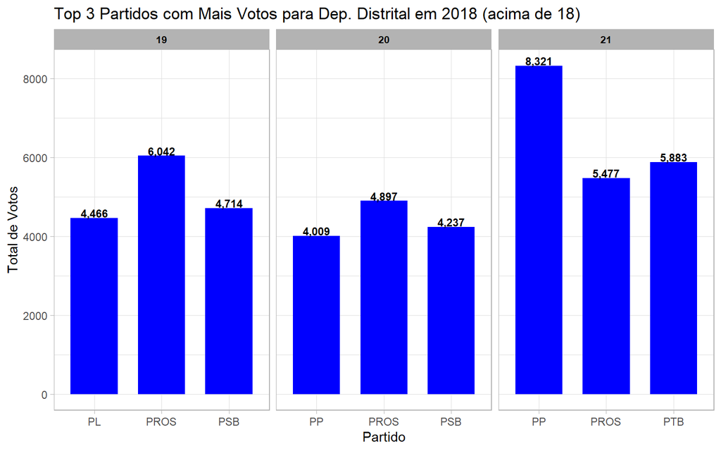

```r
# Criar gráfico das zonas acima de 19
ggplot(
  data = df_mais_votos_patido_deputado_por_zona_2018 %>% filter(zona > 18),
  mapping = aes(x = sigla_partido, y = votos_total)) +
  geom_col(fill = "blue", width = 0.7) +
  geom_text(aes(label = scales::comma(votos_total)),
            hjust = 0.5,
            vjust = -0.1,
            color = "black",
            size = 3,
            fontface = "bold") +
  facet_wrap(~ zona, scales = "free_x") +
  theme_light() +
  labs(
    title = "Top 3 Partidos com Mais Votos para Dep. Distrital em 2018 (acima de 18)",
    x = "Partido",
    y = "Total de Votos"
  ) +
theme(
  strip.text = element_text(
    face = "bold",
    color = "black",
    size = 8)
)
```

#### Top 3 Partidos que mais recebem votos por RA para Deputado Distrital em 2022

```r
# Criar o Dataframe com os dados dos top 3 partidos mais votados para Deputado Distrital por zona em 2022
df_mais_votos_patido_deputado_por_zona_2022 <- df_resultado_eleicao %>%
  filter(cargo == "deputado distrital", ano == 2022) %>%
  group_by(sigla_partido, zona) %>%
  summarise(votos_total = sum(votos)) %>%
  arrange(zona, desc(votos_total)) %>%
  group_by(zona) %>%
  slice_head(n = 3)
```

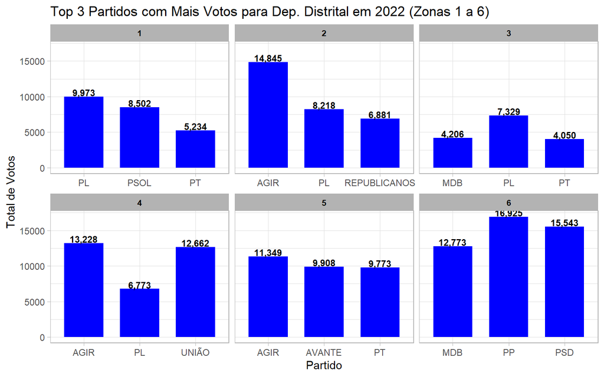

```r
# Criar gráfico das zonas 1 a 6
ggplot(
  data = df_mais_votos_patido_deputado_por_zona_2022%>% filter(zona < 7),
  mapping = aes(x = sigla_partido, y = votos_total)) +
  geom_col(fill = "blue", width = 0.7) +
  geom_text(aes(label = scales::comma(votos_total)),
            hjust = 0.5,
            vjust = -0.1,
            color = "black",
            size = 3,
            fontface = "bold") +
  facet_wrap(~ zona, scales = "free_x") +
  theme_light() +
  labs(
    title = "Top 3 Partidos com Mais Votos para Dep. Distrital em 2022 (Zonas 1 a 6)",
    x = "Partido",
    y = "Total de Votos"
  ) +
theme(
  strip.text = element_text(
    face = "bold",
    color = "black",
    size = 8)
)
```

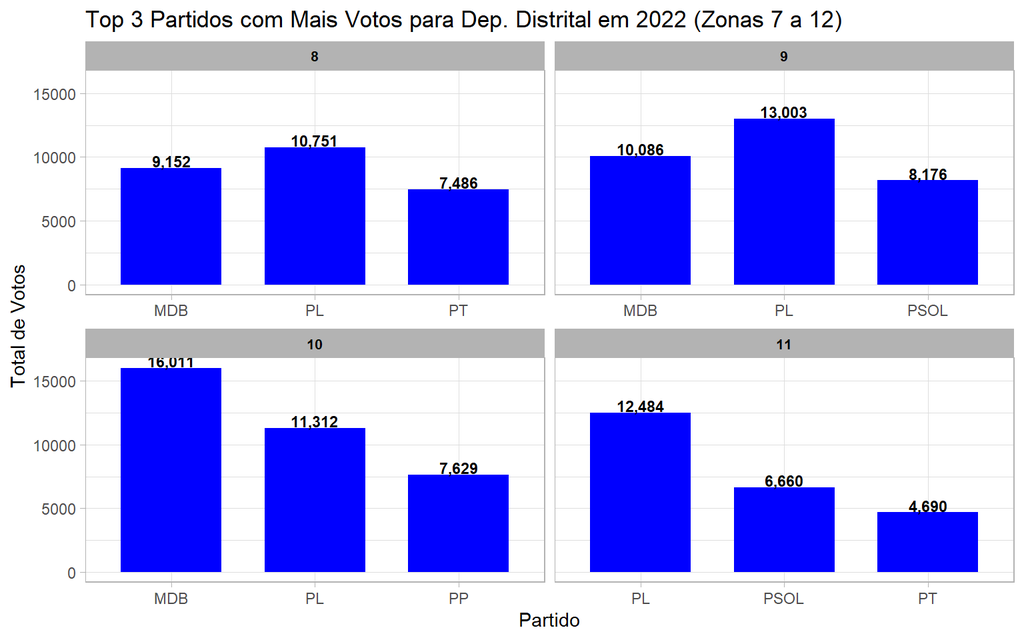

```r
# Criar gráfico das zonas 6 a 11
ggplot(
  data = df_mais_votos_patido_deputado_por_zona_2022 %>% filter(zona > 6 & zona < 13),
  mapping = aes(x = sigla_partido, y = votos_total)) +
  geom_col(fill = "blue", width = 0.7) +
  geom_text(aes(label = scales::comma(votos_total)),
            hjust = 0.5,
            vjust = -0.1,
            color = "black",
            size = 3,
            fontface = "bold") +
  facet_wrap(~ zona, scales = "free_x") +
  theme_light() +
  labs(
    title = "Top 3 Partidos com Mais Votos para Dep. Distrital em 2022 (Zonas 7 a 12)",
    x = "Partido",
    y = "Total de Votos"
  ) +
theme(
  strip.text = element_text(
    face = "bold",
    color = "black",
    size = 8)
)
```

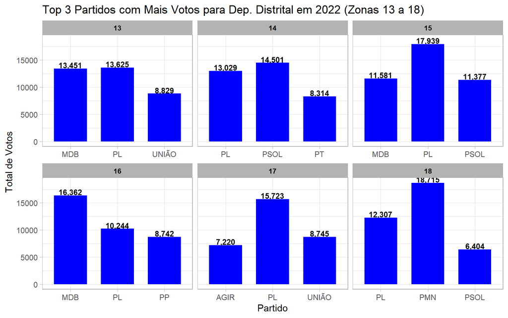

```r
# Criar gráfico das zonas de 13 a 19
ggplot(
  data = df_mais_votos_patido_deputado_por_zona_2022 %>% filter(zona > 12 & zona < 19),
  mapping = aes(x = sigla_partido, y = votos_total)) +
  geom_col(fill = "blue", width = 0.7) +
  geom_text(aes(label = scales::comma(votos_total)),
            hjust = 0.5,
            vjust = -0.1,
            color = "black",
            size = 3,
            fontface = "bold") +
  facet_wrap(~ zona, scales = "free_x") +
  theme_light() +
  labs(
    title = "Top 3 Partidos com Mais Votos para Dep. Distrital em 2022 (Zonas 13 a 18)",
    x = "Partido",
    y = "Total de Votos"
  ) +
theme(
  strip.text = element_text(
    face = "bold",
    color = "black",
    size = 8)
)
```

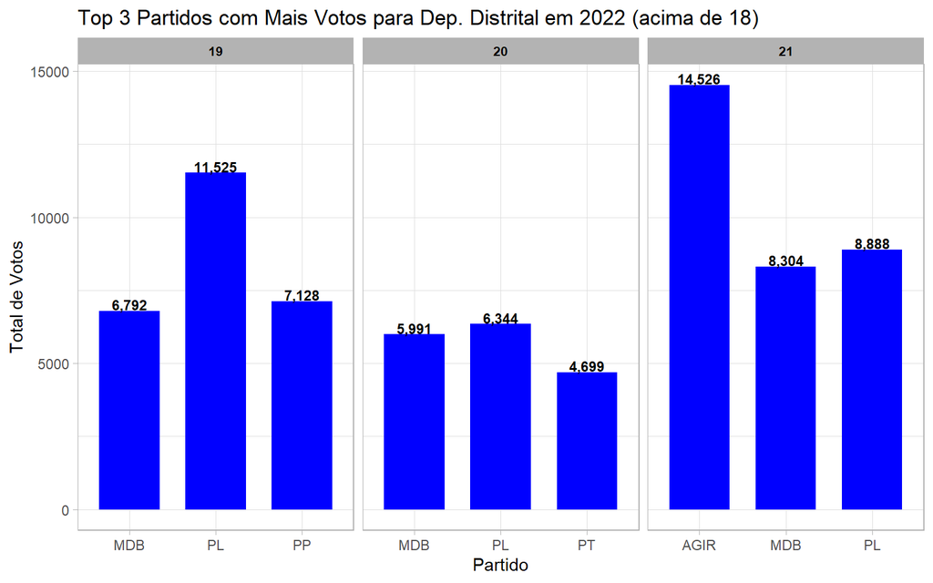

```r
# Criar gráfico das zonas acima de 19
ggplot(
  data = df_mais_votos_patido_deputado_por_zona_2022 %>% filter(zona > 18),
  mapping = aes(x = sigla_partido, y = votos_total)) +
  geom_col(fill = "blue", width = 0.7) +
  geom_text(aes(label = scales::comma(votos_total)),
            hjust = 0.5,
            vjust = -0.1,
            color = "black",
            size = 3,
            fontface = "bold") +
  facet_wrap(~ zona, scales = "free_x") +
  theme_light() +
  labs(
    title = "Top 3 Partidos com Mais Votos para Dep. Distrital em 2022 (acima de 18)",
    x = "Partido",
    y = "Total de Votos"
  ) +
theme(
  strip.text = element_text(
    face = "bold",
    color = "black",
    size = 8)
)
```

Com base nos gráficos da eleição para Deputado Distrital em 2022, a análise revela a re-ideologização do voto proporcional, com o PL e o PT polarizando a Câmara Legislativa (CLDF). Mais algumas análises são:

1. Diferente de 2018 (onde a onda Bolsonaro não se traduziu para a legenda PSL), em 2022, a polarização Executivo/Presidente se consolidou no Legislativo, com o PL e o PT disputando votos de legenda em várias Zonas.
2. Em meio à polarização, o MDB aparece no Top 3 de várias Zonas. Provavelmente influenciado pelo então governados Ibaneis (também do MDB).
3. O PSOL surge no Top 3 de diversas zonas, demostrando ter construído uma base ideológica com bastante capilaridade.

#### Análise de Pareto por nome (Presidente)

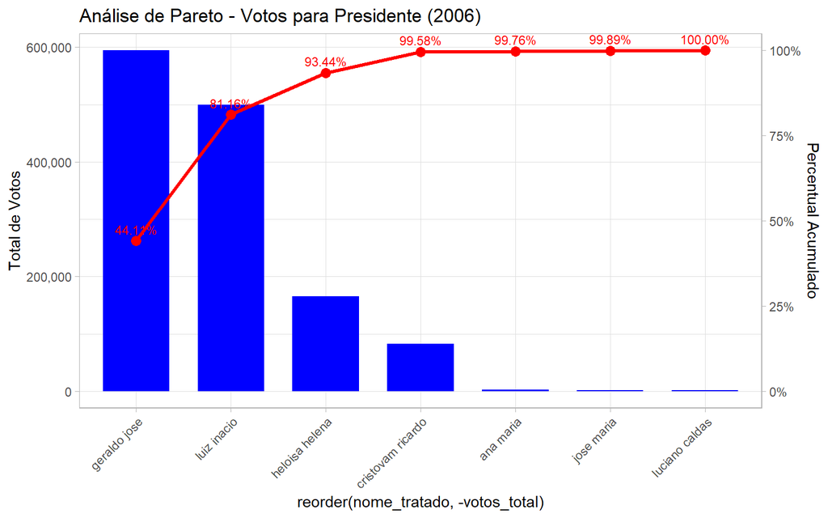

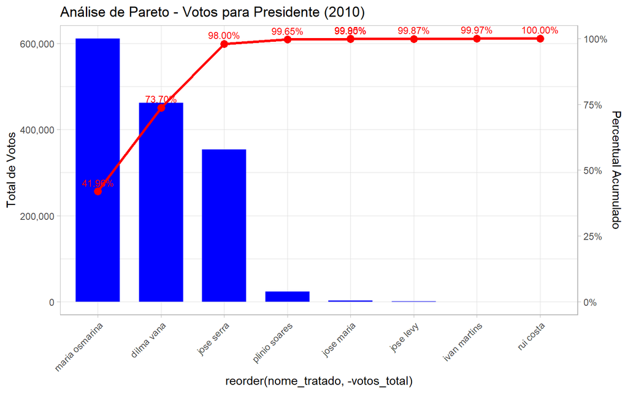

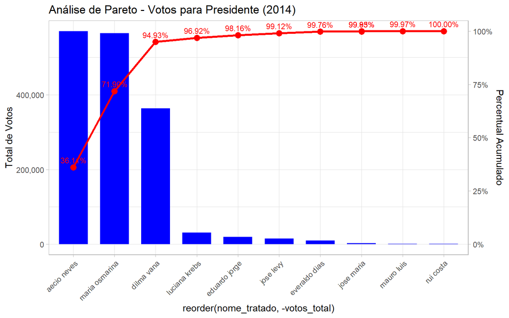

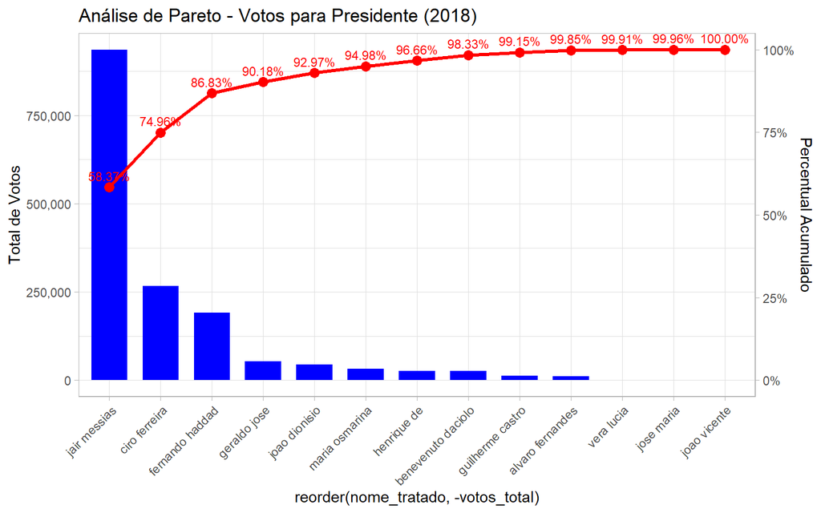

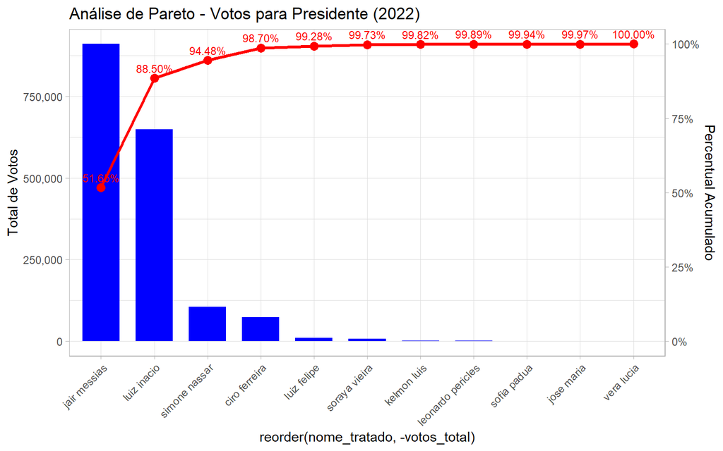

```r
# Criar dataframe para a análise de pareto
df_pareto_presidente <- df_resultado_eleicao %>%
  filter(cargo == "presidente") %>%

  # Agrupar por nome limpo
  group_by(sigla_partido, ano, nome_tratado) %>%
  summarise(
    nome_candidato = first(nome_tratado),
    votos_total = sum(votos),
    .groups = "drop"
  ) %>%

  # Pareto
  arrange(ano, desc(votos_total)) %>%
  group_by(ano) %>%
  mutate(
    total_ano = sum(votos_total),
    perc_votos = votos_total / total_ano,
    perc_acum = cumsum(perc_votos)
  ) %>%
  ungroup()

# Lista os anos presentes no dataframe para usar no loop
anos <- unique(df_pareto_presidente$ano)

# Loop para gerar um gráfico de Pareto para cada ano
walk(anos, function(ano_i) {

  df_ano <- df_pareto_presidente %>%
    filter(ano == ano_i)

  # Criar do gráfico
  p <- ggplot(df_ano, aes(x = reorder(nome_tratado, -votos_total))) +

    # Grafico de Barras representando o total de votos
    geom_col(aes(y = votos_total), fill = "blue", width = 0.7) +

    # Linha representando o percentual acumulado
    geom_line(
      aes(y = perc_acum * max(votos_total)),
      color = "red", size = 1.2, group = 1
    ) +

    # Pontos marcando cada valor da linha de percentual acumulado
    geom_point(
      aes(y = perc_acum * max(votos_total)),
      color = "red", size = 3
    ) +

    # Rotulo dos pontos da linha de percentual acumulado
    geom_text(
      aes(y = perc_acum * max(votos_total),
          label = scales::percent(perc_acum, accuracy = 0.01)),
      vjust = -0.7, size = 3, color = "red"
    ) +

    scale_y_continuous(
      name = "Total de Votos",
      labels = comma,
      sec.axis = sec_axis(
        ~ . / max(df_ano$votos_total),
        name = "Percentual Acumulado",
        labels = percent
      )
    ) +

    theme_light() +
    theme(axis.text.x = element_text(angle = 45, hjust = 1))+
    labs(
      title = paste("Análise de Pareto - Votos para Presidente (", ano_i, ")", sep = ""),

    )

  print(p)
})
```

A análise dos gráficos de Pareto para a eleição presidencial no DF (2006 a 2022) oferece uma perspectiva clara sobre o padrão de concentração eleitoral do Distrito Federal.

#### Análise de Pareto por nome (Deputado Distritual)

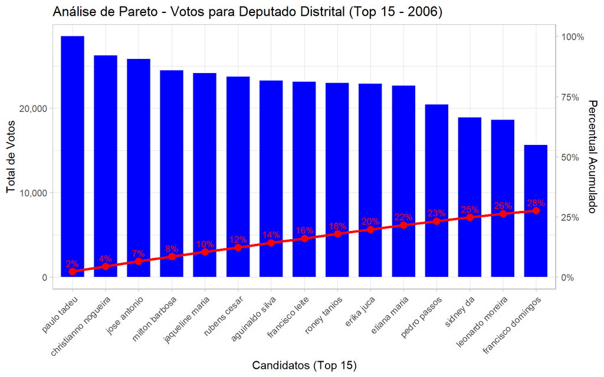

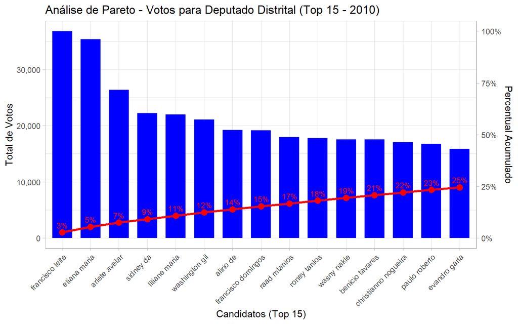

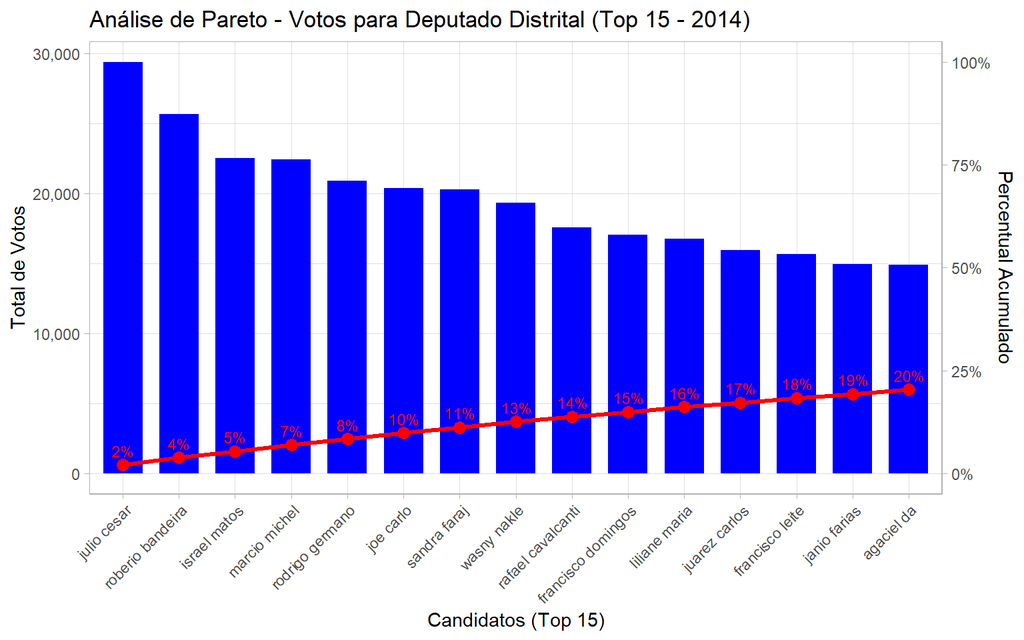

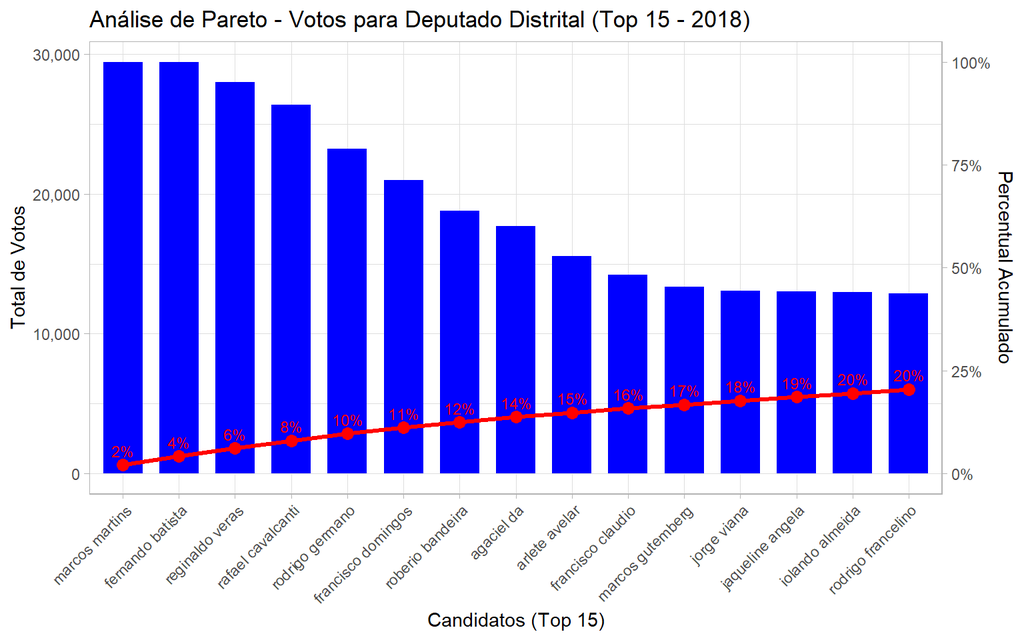

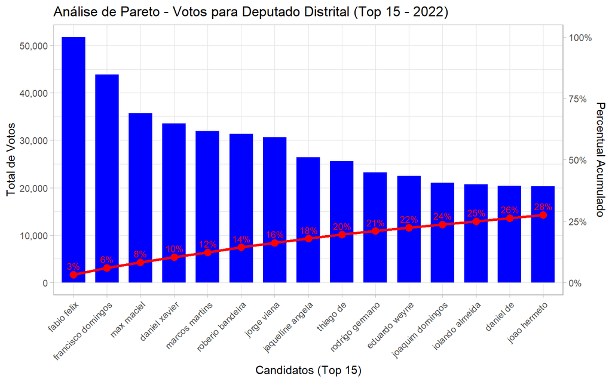

```r
# Criar dataframe para a análise de Pareto
df_pareto_deputado <- df_resultado_eleicao %>%
  filter(cargo == "deputado distrital") %>%

  # Agrupar por nome tratado
  group_by(sigla_partido, ano, nome_tratado) %>%
  summarise(
    nome_candidato = first(nome_tratado),
    votos_total = sum(votos),
    .groups = "drop"
  ) %>%

  # Ordenação inicial
  arrange(ano, desc(votos_total)) %>%

  # Cálculo percentual por ano
  group_by(ano) %>%
  mutate(
    total_ano = sum(votos_total),         # total de votos do ano
    perc_votos = votos_total / total_ano  # percentual do total
  ) %>%
  ungroup()

# Lista de anos presentes no dataframe
anos_deputado <- unique(df_pareto_deputado$ano)

# Loop para gerar gráfico de Pareto para cada ano (apenas TOP 30)
walk(anos_deputado, function(ano_i) {

  df_ano <- df_pareto_deputado %>%
    filter(ano == ano_i) %>%
    arrange(desc(votos_total)) %>%
    slice(1:15) %>%                          # seleciona apenas o TOP 25
    mutate(perc_acum = cumsum(perc_votos))   # percentual acumulado apenas dos 30

  # Criar gráfico
  p <- ggplot(df_ano, aes(x = reorder(nome_tratado, -votos_total))) +

    # Gráfico de barras representando o total de votos
    geom_col(aes(y = votos_total), fill = "blue", width = 0.7) +

    # Linha representando o percentual acumulado
    geom_line(
      aes(y = perc_acum * max(votos_total)),
      color = "red", size = 1.2, group = 1
    ) +

    # Pontos marcando cada valor da linha de percentual acumulado
    geom_point(
      aes(y = perc_acum * max(votos_total)),
      color = "red", size = 3
    ) +

    # Rotulo dos pontos da linha de percentual acumulado
    geom_text(
      aes(y = perc_acum * max(votos_total),
          label = scales::percent(perc_acum, accuracy = 1)),
      vjust = -0.7, size = 3, color = "red"
    ) +

    # Escalas de eixo: votos + percentual acumulado
    scale_y_continuous(
      name = "Total de Votos",
      labels = scales::comma,
      sec.axis = sec_axis(
        ~ . / max(df_ano$votos_total),
        name = "Percentual Acumulado",
        labels = scales::percent
      )
    ) +

    # Tema e ajustes estéticos
    theme_light() +
    theme(axis.text.x = element_text(angle = 45, hjust = 1)) +

    # Título e rótulos
    labs(
      title = paste("Análise de Pareto - Votos para Deputado Distrital (Top 15 - ", ano_i, ")", sep = ""),
      x = "Candidatos (Top 15)"
    )

  print(p)
})
```

É possivel observar uma curva de concentração suave, apresentando um contraste bem grande em relação a eleição presidencial. Mesmo com a polarização, a necessidade de eleger bancadas distribui o voto entre muitas legendas, o que pode ser um indicativo de que a fidelidade à estrutura local é maior do que a fidelidade ideológica.

### 2. Análise de correlação para verificar o Efeito Coattail

#### Correlação geral entre votos para presidente e votos para deputado distrital

O análise abaixo detalha o cálculo do Efeito Carona (Coattail Effect), ou seja, o grau em que o desempenho percentual de um partido na eleição presidencial em uma determinada Zona Eleitoral é replicado pelo desempenho percentual de seus deputados distritais eleitos na mesma zona.

O resultado será um número entre -1 e 1.

- Resultado próximo a 1 (Forte Correlação): Isso indicaria que a votação total de um partido para Presidente em uma determinada Zona Eleitoral é acompanhada por uma votação total proporcionalmente alta para seus Deputados Distritais eleitos nessa mesma Zona. Ou seja, a força do Executivo está correlacionada com a força do Legislativo local do mesmo partido, sendo um possível instrumento para confirmar o Efeito Carona (ou fidelidade à legenda).
- Resultado próximo a 0 (Fraca Correlação): Isso indicaria que a votação para Presidente e a votação para Deputado Distrital se dão de forma independente. A popularidade do candidato presidencial do partido tem pouca ou nenhuma influência sobre a votação obtida por seus candidatos eleitos na Câmara Legislativa do DF.

```r
# % presidencial por partido e zona
pres_por_partido <- df_resultado_eleicao %>%

  # Filtra apenas votos para presidente
  filter(cargo == "presidente") %>%

  # Agrupa por ano, zona e partido para somar os votos
  group_by(ano, zona, sigla_partido) %>%
  summarise(
    votos_pres = sum(votos),     # total de votos do partido na zona
    .groups = "drop"
  ) %>%

  # Junta com o total de votos para presidente por ano e zona
  left_join(
    df_resultado_eleicao %>%
      filter(cargo == "presidente") %>%          # filtra presidente novamente
      group_by(ano, zona) %>%                    # agrupa por ano e zona
      summarise(
        total_pres = sum(votos),                 # total de votos na zona
        .groups = "drop"
      ),
    by = c("ano", "zona")
  ) %>%

  # Calcula o percentual do partido na zona
  mutate(pct_pres = votos_pres / total_pres)
```

```r
# Dataframe para Deputados distritais (24 por ano)
deputados_eleitos <- df_resultado_eleicao %>%
  filter(cargo == "deputado distrital", turno == 1) %>%
  mutate(
    nome_limpo = nome_candidato %>%
      toupper() %>%
      iconv(to = "ASCII//TRANSLIT") %>%
      str_replace_all("[:punct:]", " ") %>%
      str_replace_all("\\b(DA|DE|DO|DAS|DOS| E )\\b", " ") %>%
      str_trim() %>%
      str_squish()
  ) %>%
  group_by(ano, sigla_partido, nome_limpo) %>%
  summarise(
    total_votos_candidato = sum(votos),
    nome_candidato = first(nome_candidato),   # nome original mais comum
    .groups = "drop"
  ) %>%
  group_by(ano) %>%
  arrange(desc(total_votos_candidato)) %>%
  slice_max(total_votos_candidato, n = 24, with_ties = FALSE) %>%
  ungroup() %>%
  select(ano, sigla_partido, nome_candidato, total_votos_candidato)
```

```r
# % distrital dos ELEITOS por partido e zona
distrital_eleitos_por_partido <- df_resultado_eleicao %>%
  filter(cargo == "deputado distrital") %>%
  semi_join(deputados_eleitos, by = c("ano", "sigla_partido", "nome_candidato")) %>%
  group_by(ano, zona, sigla_partido) %>%
  summarise(votos_distrital_eleitos = sum(votos), .groups = "drop") %>%
  left_join(
    df_resultado_eleicao %>%
      filter(cargo == "deputado distrital") %>%
      group_by(ano, zona) %>%
      summarise(total_distrital = sum(votos), .groups = "drop"),
    by = c("ano", "zona")
  ) %>%
  mutate(pct_distrital = votos_distrital_eleitos / total_distrital)
```

```r
# Base completa: TODOS os partidos que aparecem nos dois cargos
base_completa_coattail <- pres_por_partido %>%
  select(ano, zona, sigla_partido, pct_pres) %>%
  inner_join(distrital_eleitos_por_partido %>%
               select(ano, zona, sigla_partido, pct_distrital),
             by = c("ano", "zona", "sigla_partido"))
```

```r
# Correlação geral (todos os partidos, todas as zonas)
cor.test(base_completa_coattail$pct_pres, base_completa_coattail$pct_distrital)
```

```
##
##  Pearson's product-moment correlation
##
## data:  base_completa_coattail$pct_pres and base_completa_coattail$pct_distrital
## t = 12.086, df = 369, p-value < 2.2e-16
## alternative hypothesis: true correlation is not equal to 0
## 95 percent confidence interval:
##  0.4554230 0.6017344
## sample estimates:
##       cor
## 0.5325453
```

Com base no resultado do teste de correlação, é possivel afirmar que:

- O Efeito Coattail (efeito carona/puxar votos) é moderado, mas existente

Existe uma ligação estatisticamente significativa entre a força de um partido para Presidente em uma Zona Eleitoral e a votação de seus deputados distritais eleitos nessa mesma zona. Ou seja, a onda presidencial pode ajudar o partido no Legislativo. Contudo, o valor não está próximo de 1.0 (que indicaria uma relação quase perfeita), nem próximo de 0.8 (que seria uma correlação forte). O resultado de 0.53 confirma o que os gráficos mostraram: existe algum nível de dissociação e impede que o Efeito Coattail seja total.

- Força e autonomia das campanhas locais

A correlação moderada é o reflexo numérico da autonomia do Legislativo no Distrito Federal e do peso das campanhas individuais, independentemente da influência presidencial.A correlação moderada também leva a crer que a qualidade e a estrutura das campanhas locais para o legislativo do DF têm força suficiente para mitigar o impacto total da onda presidencial.

- Intervalo de Confiança

O intervalo de confiança de 0.455 a 0.601 indica que, se esta análise fosse repetida 100 vezes, em 95 delas o resultado estaria dentro dessa faixa.

#### Correlação por eleição entre votos para presidente e votos para deputado distrital

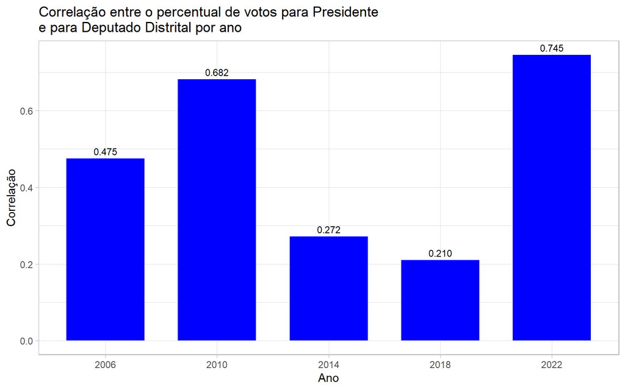

```r
correlacao_por_ano <- base_completa_coattail %>%
  group_by(ano) %>%
  summarise(
    n = n(),
    correlacao = cor(pct_pres, pct_distrital),
    r2 = summary(lm(pct_distrital ~ pct_pres))$r.squared,
    beta = coef(lm(pct_distrital ~ pct_pres))[2]
  ) %>%
  arrange(desc(correlacao))

ggplot(
  data = correlacao_por_ano,
  mapping = aes(x = factor(ano), y = correlacao)) +
  geom_col(fill = "blue", width = 0.7) +
  geom_text(aes(label = scales::comma(correlacao)),
            vjust = -0.5,
            size = 3
            ) +
  theme_light() +
  labs(
    title = "Correlação entre o percentual de votos para Presidente\ne para Deputado Distrital por ano",
    x = "Ano",
    y = "Correlação"
  ) +
theme(
  strip.text = element_text(
    face = "bold",
    color = "black",
    size = 8)
)
```

O gráfico mostra o coeficiente de Correlação de Pearson entre a votação percentual para Presidente e a votação percentual para Deputado Distrital eleito em cada ano eleitoral.

- Em 2006: Correlação Moderada (0.475)

Demonstra que, mesmo em um ano de forte polarização ideológica no Executivo para o cargo de Presidente (PT vs. PSDB), o Efeito Coattail já era limitado no DF. A força de um partido para Presidente não se traduziu diretamente em uma força proporcional equivalente para seus Deputados Distritais eleitos.

- Em 2010: Correlação Forte (0.682)

2010 apresenta uma correlação forte inesperada, sendo o segundo valor mais alto da série. Possivelmente a forte correlação não se deve ao PV em si, mas sim ao fato de que os principais partidos na eleição para deputado distrital (PT, PSDB) também tiveram votações altas no Executivo (Dilma e Serra). O coattail funcionou para os partidos tradicionais que estavam bem posicionadas na eleição presidencial.

- Em 2014 e 2018: Correlação Fraca (0.272 e 0.210)

Os anos de 2014 e 2018 representam a independência máxima do Legislativo do DF em relação à disputa presidencial. Em 2014, a briga acirrada no Executivo (PSDB vs. PSB/Marina) não se traduziu em apoio para essas legendas no Legislativo. E em 2018, a anda Bolsonaro no Executivo foi totalmente incapaz de transferir votos para seus candidatos distritais. O voto foi quase totalmente dissociado.

- Em 2022: Correlação Forte (0.745)

O ano de 2022 estabelece a correlação mais alta dos anos analisados. Este valor parece apontar o sucesso da polarização do voto no DF. Os dois polos ideológicos (PL e PT) conseguiram construir ou reorganizar estruturas partidárias locais (candidatos a Distrital eleitos) eficientes, capazes de absorver e canalizar o voto da onda presidencial.

A correlação demonstra que, em 2022, o voto ideológico para Presidente e a escolha do Deputado Distrital estavam mais alinhados do que em qualquer outro pleito.

### 3. Quais ferramentas utilizadas na análise?

Linguagem R

### 4. Como essas informações ajudarão a responder às suas perguntas de negócios?

A análise fornece uma visão quantitativa e histórica da dinâmica do voto no Distrito Federal.

Para a pergunta central: “Existe correlação forte entre o voto presidencial e o voto distrital?” A análise responde:

- A correlação não é forte de forma consistente. Ela é cíclica e volátil, flutuando de fraca (0.210 em 2018) para forte (0.745 em 2022). Mas é moderada quando analisada de maneira geral (0.532), o que pode indicar uma influência moderada no Legislativo, mas não determinante. O Efeito Coattail é um fator estratégico de oportunidade no DF. Ele parece se manifestar de forma forte quando os grandes polos ideológicos conseguem construir máquinas locais robustas (como em 2022). Em cenários de crise ou voto de protesto (2014 e 2018), a influência presidencial é baixa, garantindo a autonomia do Legislativo e permitindo que as campanhas locais tenham mais força.

### 5. Como essas informações poderiam ser aplicadas?

A análise pode oferecer três diretrizes principais:

1. Como modelar a campanha: Efeito Coattail vs Máquina própria?

Se um candidato for de um partido sem estrutura local, a análise parece demonstrar que apostar apenas na popularidade do Presidente é arriscado como estratégia de campanha. A melhor estratégia pode ser priorizar a capilaridade no bairro, o voto de nicho e o voto assistencialista. No entanto, se o candidato for do PL ou PT (ou qualquer outro partido que lidera o cenário de polarização em eleições futuras), a análise incentiva o alinhamento total com o Executivo Federal, pois a onda ideológica tem uma alta probabilidade de puxar seus votos. No entanto, a principal ressalva para a estratégia de alinhamento total (para partidos polarizados como PL/PT) é o risco de rejeição localizada e a volatilidade da onda ideológica.

2. Mapeamento de riscos e oportunidades

A análise do desempenho dos partidos nas Zonas Eleitorais pode mostrar onde o voto é mais independente ou influenciado. A busca deve ser por zonas de oportunidade (onde a campanha local é mais forte), estas são as Zonas onde o partido presidencial ganhou o Executivo, mas a legenda não dominou o Legislativo. E por evitar as zonas de risco, que são as zonas onde o partido presidencial ganhou o Executivo e sua legenda dominou o Legislativo.

### 6. Existem dados e análises adicionais que poderiam ser usadas para expandir as descobertas?

- Correlação por Zona eleitora: Identificar as Zonas onde o voto para Distrital é consistentemente independente e onde ele é totalmente dependente da onda presidencial históricamente.
- Análise da transferência do voto nulo/branco: Entender a relação entre a rejeição ao sistema e a força das campanhas locais.
- Correlação com o resultado para governador (executivo local): Calcular a correlação entre o percentual de votos para Governador (Vencedor) e o voto para Deputados Distritais eleitos, por partido. Essa análise demonstraria se o Efeito Coattail do Governador é mais forte ou mais fraco que o Efeito Coattail do Presidente no DF.

### 7. Limitações dessa análise

- Não se pode afirmar que o eleitor individual que votou no Presidente X também votou no Distrital Y. A correlação apenas demonstra a eficiência da agregação de votos do partido na Zona, sem capturar o voto individual.
- A métrica de Distrital utilizada considera apenas os votos dos candidatos que foram eleitos. Isso pode subestimar o Efeito Coattail total do partido. Se o alto voto presidencial impulsionou vários candidatos (que, juntos, somaram muitos votos), mas nenhum atingiu o quociente eleitoral, essa influência não é totalmente capturada no cálculo.
- O Coeficiente de Pearson demonstra uma associação, mas não comprova causalidade.
- A correlação ao longo dos anos eleitorais apresentou uma volatilidade muito grande. O período analisado também é muito curto para tentar relizar qualquer previsão baseada em dados históricos.

## CONCLUSÃO

Ao longo das eleições, a correlação variou significativamente. Essa volatilidade reflete ciclos de polarização nacional, com maior alinhamento em anos de consolidação ideológica (como 2022, marcado pelo duelo PT-PL) e maior autonomia local em períodos de protesto ou fragmentação (como 2018, onde a onda bolsonarista não se transferiu para o PSL no legislativo). As análises exploratórias, incluindo gráficos de Pareto e distribuições por zona eleitoral, confirmam a desconexão parcial entre o voto executivo e legislativo local, destacando a resiliência de estruturas partidárias locais e a influência de campanhas individuais.

Em suma, o efeito coattail presidencial no DF é cíclico e moderado, reforçando a necessidade de equilíbrio entre alinhamento nacional e autonomia local na dinâmica eleitoral.